# Multiattribute Linear Ballistic Accumulator

Lars M. Reich

The Multiattribute Linear Ballistic Accumulator (MLBA) from Trueblood, Brown, and Heathcote (2014) is originally only for three choices with respectively two-attribute tasks. This document is a step for step instruction to extend the MLBA to multiattribute tasks. Therefor the R code from https://osf.io/4p3br/ (driftFunctions.R) is presented, adopted and explained.

The function $getDrifts()$ samples the frontend process of the LBA and makes the M(ultriattribute) to the LBA. This function requires a stimuli-matrix input (named as stimuli) which contains the numeric values of the attributes for each choice option. $I\_0$ is called the basic rate of accumualtion speed. $m$ is needed to map all the subjected attribute values. $lambda1$ and $lambda2$ are weights for each comparison between the attributes. $gamma$ is needed to scale the drift rate. $beta$ is a parameter to differ the attributes from each other.

All in all this function returns the driftrate for each choice option (compare equation 1a, 1b and 1c in Trueblood, Brown, and Heathcote (2014)). To extend this function, we will have a closer look at the function $CurveFun()$, $Valuation()$ as well as all dependencies.

```r
getDrifts=function(stimuli, I_0, m, lambda1, lambda2 , gamma , beta) {

  # Calculates the mean drift rates for MLBA
  # stimuli is a 3x2 matrix with the attributes of each option

  # Beta seems to be a multiplier that is applied to the second attribute
  # to allow it to differ from the first
  # Gamma seems to be a multiplier to transform things to "drift scale"

  d=rep(NA,3)

  u1 = CurveFun(stimuli[1,1:2], m)
  u2 = CurveFun(stimuli[2,1:2], m)
  u3 = CurveFun(stimuli[3,1:2], m)

  d[1] = gamma*Valuation(u1, u2, lambda1, lambda2 , beta) +
         gamma*Valuation(u1, u3, lambda1, lambda2 , beta) + I_0

  d[2] = gamma*Valuation(u2, u1, lambda1, lambda2 , beta) +
         gamma*Valuation(u2, u3, lambda1, lambda2 , beta) + I_0

  d[3] = gamma*Valuation(u3, u1, lambda1, lambda2 , beta) +
         gamma*Valuation(u3, u2, lambda1, lambda2 , beta) + I_0

  if (sum(is.na(d)) > 0) return(-Inf)

  if (max(d) < 0) {
    #stop("Highest drift is less than 0")
    d=rep(0,3)
  }

  d
}
```

# 1 CurveFun

This function expects two arguments ($option$ and $m$) and returns the subjected attribute values. The first argument ($option$) is a vector which contains the attribute values. The later argument $m$ is a scalar to map the subjected values on the curve $1 = (\frac{x}{a})^m + (\frac{y}{b})^m$. Larger values ($m>1$ and $m<-1$) of $m$ makes the curve convex $-$ smaller values ($-1 < m < 1$) makes the curve concave. A vector $u$ with the length of the number of attributes is created and contains NA. All intercepts of the curve are fixed to the sum of the attributes $a = b = option[1] + option[2]$. The angle between the x-axis and the attribute vector is calculated: $angle = atan(\frac{option[2]}{option[1]})$. Because the subjected values have to be (per definition) part the curve, these coordinates are calculated as following: $u[1] = \frac{b}{\sqrt[m]{tan(angle)^m+(\frac{b}{a})^m}}$ and $u[2] = b*(1-\sqrt[m]{(\frac{u[1]}{a})^m})$

```r
CurveFun=function(option, m) {

  u=rep(NA,2)

  # Mapping objective to subjective values (Appendix C)

  # x and y intercepts of the line of indifference, which is in the direction
  # of the unit-length vector 1/sqrt(2)*[-1,1]'
  a = option[1] + option[2]
  b = a
  # angle between x-axis and the vector <option(1), option(2)>
  angle = atan(option[2]/option[1])
  # subjective values for the option on the curve (x/a)^m + (y/b)^m
  u[1] = b/((tan(angle))^m+(b/a)^m)^(1/m)
  u[2] = b*(1-(u[1]/a)^m)^(1/m)
  u
}
```

## 1.1 Explanation: Two Attributes

For one choice option with two attributes (e.g. $x=5$ and $y=3$) the angle between subjected attribute vector and the x-axis is calculated to 31 degree. The subjected values are calculated to $u1 = 7$ and $u2 = 4$.

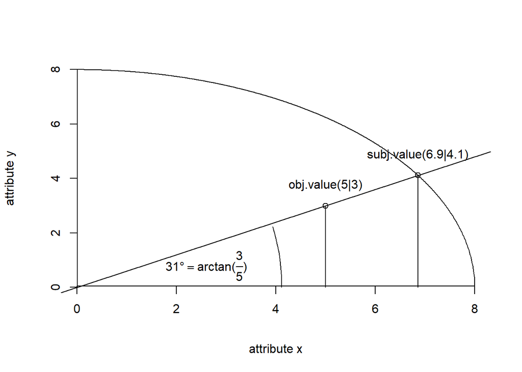

To extend the function $CurveFun$ to multiattributes, the number of attributes is extracted from the length of the input vector $option$. The vector $u$ is set to the length of number of attributes. The intercepts $a$ of the curce are set to the sum of all attributes (for more than two attributes the curve will be a n-dimensional level, with $n$ as the number of attributes). The vector $att\_value$ contains the square of each attribute which is later needed to calculate the distance to the objective attribute in space. The formula: $angle[i] = atan(\frac{option[i]}{\sqrt{(sum(att\_value[-i]))}})$ calculates the angle between the subjected attribute vector ($option[i]$) and each axis. This formula is equal to $angle = atan(\frac{option[2]}{option[1]})$. (e.g. $i=2$: than $att\_value[-2] = option[1]²$ and $angle[2] = atan(\frac{option[2]}{\sqrt{option[1]²}}) = atan(\frac{option[2]}{option[1]})$ )

```r
option <- c(5,3)
m <- 2
#Evans, Trueblood and Holmes:
  u = rep(NA,2)
  a = option[1] + option[2]
  b = a
  angle = atan(option[2]/option[1])
```

[output not shown]

[output not shown]

Trueblood, Brown, and Heathcote (2014) calculates the second subjective attribute value by inserting the outcome for the first subjected value in the curve $1 = (\frac{x}{a})^m + (\frac{y}{b})^m$. The example Code below shows, how the angle between every axis and the objective/subjective attribute can be calculated:

```r
option <- c(5,3)
  m <- 2
  nr_att <- length(option)
  subj_value_att <- rep(NA, nr_att)
  a <- rep(sum(option[1:nr_att]), nr_att)

  att_value <- numeric()
  angle1 <- vector(mode = "numeric", length = nr_att)

  for (i in 1:nr_att){
    att_value <- c(att_value, (option[i])^2)
  }
  for (i in 1:nr_att){
    angle1[i] <- atan(option[i]/sqrt(sum(att_value[-i])))
  }
for(i in 1:2){#  works only for two attributes
subj_value_att[i] <- a[1]/( (tan(angle1[i]))^m + 1 )^(1/m)}
# these are the subjective values. compare with two
# attributes plot on page 3
print(round(subj_value_att),1)
```

```
## [1] 4 7
```

The next chapter visualize the calculation for three attributes.